# Thành viên nhóm

- Nguyễn Thanh Bình - 20133025
- Nguyễn Nhật Triều - 20133102
- Đoàn Quốc Trung - 20133104

# Giới thiệu tổng quan đề tài

### 1. Đề xuất và động lực

- Vấn đề dân số là một vấn đề nhức nhối gây ra nhiều hệ lụy cho xã hội .
- Đó là lý do nhóm chúng tôi làm bài phân tích về dân số các khu vực trên thế giới năm 2020
- Từ đó đưa ra kết luận , so sánh đánh giá chung về tình hình dân số của các khu vực trên thế giới

[figure not shown]

### 2. Tóm tắt và đặt ra giả thuyết

- Tên đề tài: Nghiên cứu về dân số ước tính hiện tại của các nước trên thế giới .
- Nguồn tải: https://www.kaggle.com/datasets/anandhuh/countries-in-the-world-by-population-2022
- Nguồn thu thập dữ liệu: https://worldpopulationreview.com/
- Cách thu thập dữ liệu : Thực hiện khảo sát dân số ở từng quốc gia , từng khu vực.
- Đặt giả thuyết:

  H0 : Mật độ dân số khu vực Châu Âu lớn hơn Châu Phi

  H1 : Số người di cư đến khu vực Bắc Mỹ lớn hơn Nam Mỹ

  H2 : Tỉ lệ sinh sản Châu Á nhỏ hơn Châu Âu

# Mô hình hóa và trực quan hóa dữ liệu

```python
import pandas as pd
df = pd.read_csv('world_population.csv')
df.head(10)
```

|  | Country/Other | Population (2020) | Yearly Change | Net Change | Density (P/Km²) | Land Area (Km²) | Migrants (net) | Fert. Rate | Med. Age | Urban Pop % | World Share |
| --- | --- | --- | --- | --- | --- | --- | --- | --- | --- | --- | --- |
| 0 | Afghanistan | 38928346 | 2.33 | 886592 | 60 | 652860 | -62920 | 4.6 | 18 | 25.0 | 0.50 |
| 1 | Albania | 2877797 | -0.11 | -3120 | 105 | 27400 | -14000 | 1.6 | 36 | 63.0 | 0.04 |
| 2 | Algeria | 43851044 | 1.85 | 797990 | 18 | 2381740 | -10000 | 3.1 | 29 | 73.0 | 0.56 |
| 3 | Angola | 32866272 | 3.27 | 1040977 | 26 | 1246700 | 6413 | 5.6 | 17 | 67.0 | 0.42 |
| 4 | Antigua and Barbuda | 97929 | 0.84 | 811 | 223 | 440 | 0 | 2.0 | 34 | 26.0 | 0.00 |
| 5 | Argentina | 45195774 | 0.93 | 415097 | 17 | 2736690 | 4800 | 2.3 | 32 | 93.0 | 0.58 |
| 6 | Armenia | 2963243 | 0.19 | 5512 | 104 | 28470 | -4998 | 1.8 | 35 | 63.0 | 0.04 |
| 7 | Aruba | 106766 | 0.43 | 452 | 593 | 180 | 201 | 1.9 | 41 | 44.0 | 0.00 |
| 8 | Australia | 25499884 | 1.18 | 296686 | 3 | 7682300 | 158246 | 1.8 | 38 | 86.0 | 0.33 |
| 9 | Austria | 9006398 | 0.57 | 51296 | 109 | 82409 | 65000 | 1.5 | 43 | 57.0 | 0.12 |

```python
print('Số quan sát:', len(df))
```

```
Số quan sát: 200
```

```python
print('Số chiều:', df.shape)
```

```
Số chiều: (200, 11)
```

```python
df.info()
```

```
<class 'pandas.core.frame.DataFrame'>
RangeIndex: 200 entries, 0 to 199
Data columns (total 11 columns):
Country/Other        200 non-null object
Population (2020)    200 non-null int64
Yearly Change        200 non-null float64
Net Change           200 non-null int64
Density (P/Km²)      200 non-null int64
Land Area (Km²)      200 non-null int64
Migrants (net)       200 non-null int64
Fert. Rate           200 non-null float64
Med. Age             200 non-null int64
Urban Pop %          193 non-null float64
World Share          200 non-null float64
dtypes: float64(4), int64(6), object(1)
memory usage: 17.3+ KB
```

```python
Max=max(df['Population (2020)'])
df[df['Population (2020)']==Max]['Country/Other']
```

```
35    China
Name: Country/Other, dtype: object
```

```python
Min=min(df['Population (2020)'])
df[df['Population (2020)']==Min]['Country/Other']
```

```
4    Antigua and Barbuda
Name: Country/Other, dtype: object
```

### Biểu đồ trực quan hóa

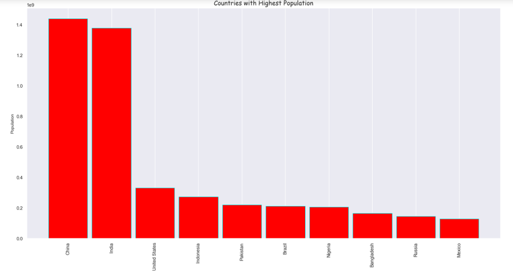

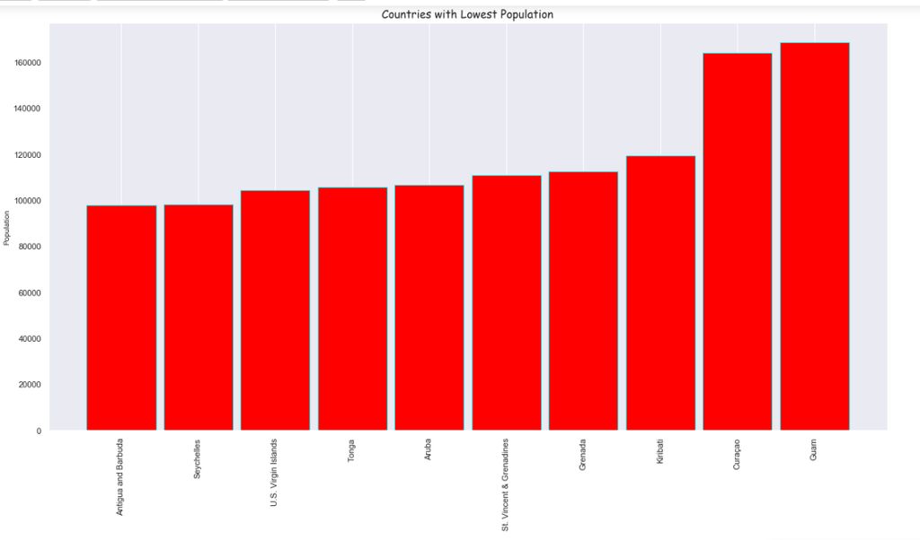

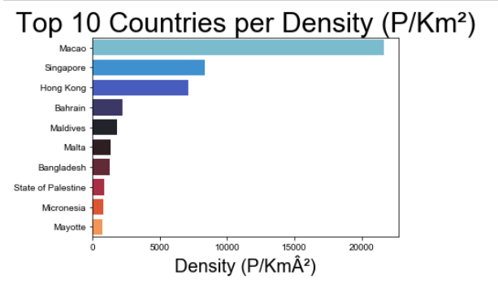

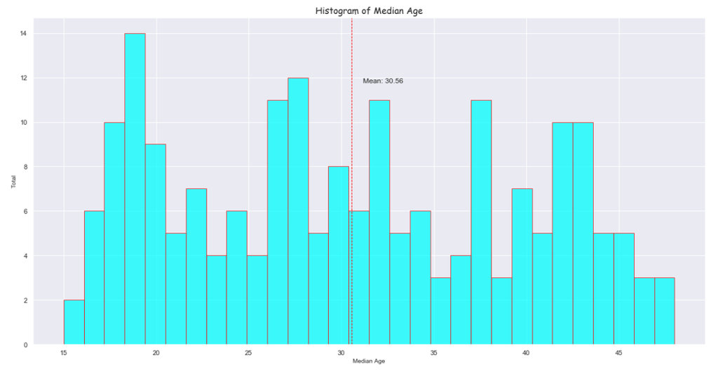

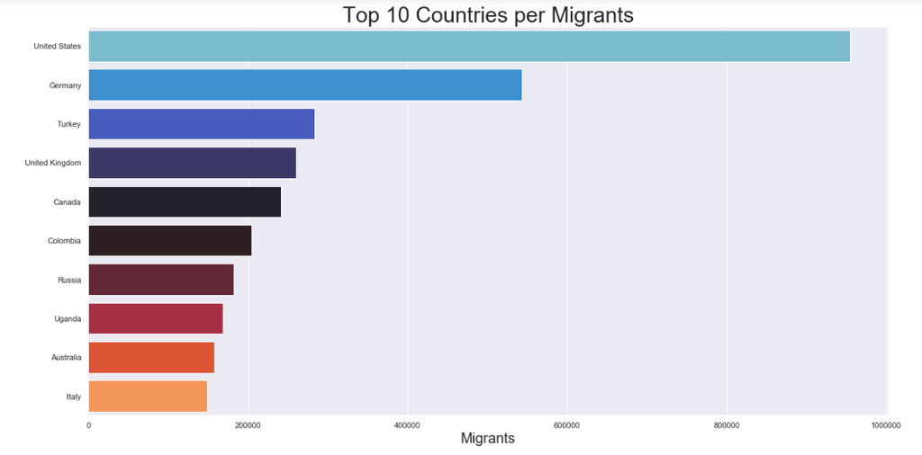

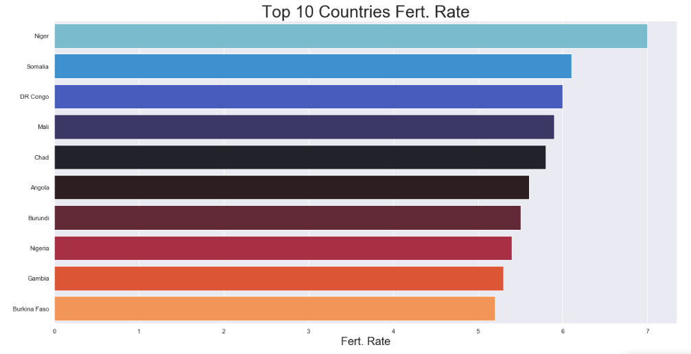

# Phân tích thống kê

```python
import pandas as pd
data = pd.read_csv('contients_population.csv')
data1=data
data1
```

|  | Country/Other | Population (2020) | Yearly Change | Net Change | Density (P/Km²) | Land Area (Km²) | Migrants (net) | Fert. Rate | Med. Age | Urban Pop % | World Share | Area |
| --- | --- | --- | --- | --- | --- | --- | --- | --- | --- | --- | --- | --- |
| 0 | Argentina | 45195774 | 0.93 | 415097 | 17 | 2736690 | 4800 | 2.3 | 32 | 93.0 | 0.58 | South American |
| 1 | Venezuela | 28435940 | -0.28 | -79889 | 32 | 882050 | -653249 | 2.3 | 30 | NaN | 0.36 | South American |
| 2 | Brazil | 212559417 | 0.72 | 1509890 | 25 | 8358140 | 21200 | 1.7 | 33 | 88.0 | 2.73 | South American |
| 3 | Bolivia | 11673021 | 1.39 | 159921 | 11 | 1083300 | -9504 | 2.8 | 26 | 69.0 | 0.15 | South American |
| 4 | Chile | 19116201 | 0.87 | 164163 | 26 | 743532 | 111708 | 1.7 | 35 | 85.0 | 0.25 | South American |
| 5 | Colombia | 50882891 | 1.08 | 543448 | 46 | 1109500 | 204796 | 1.8 | 31 | 80.0 | 0.65 | South American |
| 6 | Ecuador | 17643054 | 1.55 | 269392 | 71 | 248360 | 36400 | 2.4 | 28 | 63.0 | 0.23 | South American |
| 7 | Guyana | 786552 | 0.48 | 3786 | 4 | 196850 | -6000 | 2.5 | 27 | 27.0 | 0.01 | South American |
| 8 | Peru | 32971854 | 1.42 | 461401 | 26 | 1280000 | 99069 | 2.3 | 31 | 79.0 | 0.42 | South American |
| 9 | Guinea | 13132795 | 2.83 | 361549 | 53 | 245720 | -4000 | 4.7 | 18 | 39.0 | 0.17 | South American |
| 10 | Paraguay | 7132538 | 1.25 | 87902 | 18 | 397300 | -16556 | 2.4 | 26 | 62.0 | 0.09 | South American |
| 11 | Suriname | 586632 | 0.90 | 5260 | 4 | 156000 | -1000 | 2.4 | 29 | 65.0 | 0.01 | South American |
| 12 | Uruguay | 3473730 | 0.35 | 11996 | 20 | 175020 | -3000 | 2.0 | 36 | 96.0 | 0.04 | South American |
| 13 | Antigua and Barbuda | 97929 | 0.84 | 811 | 223 | 440 | 0 | 2.0 | 34 | 26.0 | 0.00 | North American |
| 14 | Aruba | 106766 | 0.43 | 452 | 593 | 180 | 201 | 1.9 | 41 | 44.0 | 0.00 | North American |
| 15 | Bahamas | 393244 | 0.97 | 3762 | 39 | 10010 | 1000 | 1.8 | 32 | 86.0 | 0.01 | North American |
| 16 | Barbados | 287375 | 0.12 | 350 | 668 | 430 | -79 | 1.6 | 40 | 31.0 | 0.00 | North American |
| 17 | Belize | 397628 | 1.86 | 7275 | 17 | 22810 | 1200 | 2.3 | 25 | 46.0 | 0.01 | North American |
| 18 | Canada | 37742154 | 0.89 | 331107 | 4 | 9093510 | 242032 | 1.5 | 41 | 81.0 | 0.48 | North American |
| 19 | Costa Rica | 5094118 | 0.92 | 46557 | 100 | 51060 | 4200 | 1.8 | 33 | 80.0 | 0.07 | North American |
| 20 | Cuba | 11326616 | -0.06 | -6867 | 106 | 106440 | -14400 | 1.6 | 42 | 78.0 | 0.15 | North American |
| 21 | Curacao | 164093 | 0.41 | 669 | 370 | 444 | 515 | 1.8 | 42 | 89.0 | 0.00 | North American |
| 22 | Dominican Republic | 10847910 | 1.01 | 108952 | 225 | 48320 | -30000 | 2.4 | 28 | 85.0 | 0.14 | North American |
| 23 | El Salvador | 6486205 | 0.51 | 32652 | 313 | 20720 | -40539 | 2.1 | 28 | 73.0 | 0.08 | North American |
| 24 | Greece | 10423054 | -0.48 | -50401 | 81 | 128900 | -16000 | 1.3 | 46 | 85.0 | 0.13 | North American |
| 25 | Guadeloupe | 400124 | 0.02 | 68 | 237 | 1690 | -1440 | 2.2 | 44 | NaN | 0.01 | North American |
| 26 | Guatemala | 17915568 | 1.90 | 334096 | 167 | 107160 | -9215 | 2.9 | 23 | 52.0 | 0.23 | North American |
| 27 | Haiti | 11402528 | 1.24 | 139451 | 414 | 27560 | -35000 | 3.0 | 24 | 57.0 | 0.15 | North American |
| 28 | Honduras | 9904607 | 1.63 | 158490 | 89 | 111890 | -6800 | 2.5 | 24 | 57.0 | 0.13 | North American |
| 29 | Jamaica | 2961167 | 0.44 | 12888 | 273 | 10830 | -11332 | 2.0 | 31 | 55.0 | 0.04 | North American |
| ... | ... | ... | ... | ... | ... | ... | ... | ... | ... | ... | ... | ... |
| 70 | Mongolia | 3278290 | 1.65 | 53123 | 2 | 1553560 | -852 | 2.9 | 28 | 67.0 | 0.04 | Asian |
| 71 | Myanmar | 54409800 | 0.67 | 364380 | 83 | 653290 | -163313 | 2.2 | 29 | 31.0 | 0.70 | Asian |
| 72 | Nepal | 29136808 | 1.85 | 528098 | 203 | 143350 | 41710 | 1.9 | 25 | 21.0 | 0.37 | Asian |
| 73 | North Korea | 25778816 | 0.44 | 112655 | 214 | 120410 | -5403 | 1.9 | 35 | 63.0 | 0.33 | Asian |
| 74 | Philippines | 109581078 | 1.35 | 1464463 | 368 | 298170 | -67152 | 2.6 | 26 | 47.0 | 1.41 | Asian |
| 75 | Singapore | 5850342 | 0.79 | 46005 | 8358 | 700 | 27028 | 1.2 | 42 | NaN | 0.08 | Asian |
| 76 | South Korea | 51269185 | 0.09 | 43877 | 527 | 97230 | 11731 | 1.1 | 44 | 82.0 | 0.66 | Asian |
| 77 | Thailand | 69799978 | 0.25 | 174396 | 137 | 510890 | 19444 | 1.5 | 40 | 51.0 | 0.90 | Asian |
| 78 | Vietnam | 97338579 | 0.91 | 876473 | 314 | 310070 | -80000 | 2.1 | 32 | 38.0 | 1.25 | Asian |
| 79 | Algeria | 43851044 | 1.85 | 797990 | 18 | 2381740 | -10000 | 3.1 | 29 | 73.0 | 0.56 | Africal |
| 80 | Angola | 32866272 | 3.27 | 1040977 | 26 | 1246700 | 6413 | 5.6 | 17 | 67.0 | 0.42 | Africal |
| 81 | Togo | 8278724 | 2.43 | 196358 | 152 | 54390 | -2000 | 4.4 | 19 | 43.0 | 0.11 | Africal |
| 82 | Libya | 6871292 | 1.38 | 93840 | 4 | 1759540 | -1999 | 2.3 | 29 | 78.0 | 0.09 | Africal |
| 83 | Liberia | 5057681 | 2.44 | 120307 | 53 | 96320 | -5000 | 4.4 | 19 | 53.0 | 0.06 | Africal |
| 84 | Angola | 32866272 | 3.27 | 1040977 | 26 | 1246700 | 6413 | 5.6 | 17 | 67.0 | 0.42 | Africal |
| 85 | Tunisia | 11818619 | 1.06 | 123900 | 76 | 155360 | -4000 | 2.2 | 33 | 70.0 | 0.15 | Africal |
| 86 | Egypt | 102334404 | 1.94 | 1946331 | 103 | 995450 | -38033 | 3.3 | 25 | 43.0 | 1.31 | Africal |
| 87 | Seychelles | 98347 | 0.62 | 608 | 214 | 460 | -200 | 2.5 | 34 | 56.0 | 0.00 | Africal |
| 88 | South Sudan | 11193725 | 1.19 | 131612 | 18 | 610952 | -174200 | 4.7 | 19 | 25.0 | 0.14 | Africal |
| 89 | Sudan | 43849260 | 2.42 | 1036022 | 25 | 1765048 | -50000 | 4.4 | 20 | 35.0 | 0.56 | Africal |
| 90 | Congo | 5518087 | 2.56 | 137579 | 16 | 341500 | -4000 | 4.5 | 19 | 70.0 | 0.07 | Africal |
| 91 | DR Congo | 89561403 | 3.19 | 2770836 | 40 | 2267050 | 23861 | 6.0 | 17 | 46.0 | 1.15 | Africal |
| 92 | Uganda | 45741007 | 3.32 | 1471413 | 229 | 199810 | 168694 | 5.0 | 17 | 26.0 | 0.59 | Africal |
| 93 | Eritrea | 3546421 | 1.41 | 49304 | 35 | 101000 | -39858 | 4.1 | 19 | 63.0 | 0.05 | Africal |
| 94 | Ethiopia | 114963588 | 2.57 | 2884858 | 115 | 1000000 | 30000 | 4.3 | 19 | 21.0 | 1.47 | Africal |
| 95 | Burundi | 11890784 | 3.12 | 360204 | 463 | 25680 | 2001 | 5.5 | 17 | 14.0 | 0.15 | Africal |
| 96 | Benin | 12123200 | 2.73 | 322049 | 108 | 112760 | -2000 | 4.9 | 19 | 48.0 | 0.16 | Africal |
| 97 | Tanzania | 59734218 | 2.98 | 1728755 | 67 | 885800 | -40076 | 4.9 | 18 | 37.0 | 0.77 | Africal |
| 98 | Nigeria | 206139589 | 2.58 | 5175990 | 226 | 910770 | -60000 | 5.4 | 18 | 52.0 | 2.64 | Africal |
| 99 | Niger | 24206644 | 3.84 | 895929 | 19 | 1266700 | 4000 | 7.0 | 15 | 17.0 | 0.31 | Africal |

100 rows × 12 columns